# Yu Fu Random Forest

Yu Fu

12/8/2021

## Load data and data wrangling

We are using two COVID-19 dataset, the first one contains data up until 04/15/2021 and the second one contains data through the end our of study period 10/31/21.

Since Utal reported incomplete information on COVID-19 confirmed cases and deaths, we will exclude Utah from our analysis. We further excluded county with missing value.

```r
## load the data up to 10/31 and 04/15, and create a variable for county-level COVID-19 death rate
aggregate_pm_census_cdc_210415 <- read_csv("./Data/aggregate_pm_census_cdc_210415.csv")
aggregate_pm_census_cdc_211031 <- read_csv("./Data/aggregate_pm_census_cdc_211031.csv")
df_complete_1031 <- aggregate_pm_census_cdc_211031 %>% mutate(rate = (Deaths / (Population / 100000)))
names(df_complete_1031)

df_complete_0415 <- aggregate_pm_census_cdc_210415 %>% mutate(rate = (Deaths / (Population / 100000)))
names(df_complete_0415)
```

## Load data

```r
## load preprocessed data by XB, create a variable for county-level COVID-19 death rate
df_complete <- aggregate_pm_census_cdc_211031 %>% mutate(rate = (Deaths / (Population / 100000)))
names(df_complete)
```

```
##  [1] "fips"                    "mean_pm25"
##  [3] "mean_winter_temp"        "mean_summer_temp"
##  [5] "mean_winter_rm"          "mean_summer_rm"
##  [7] "Admin2"                  "Province_State"
##  [9] "Country_Region"          "Last_Update"
## [11] "Lat"                     "Long_"
## [13] "Confirmed"               "Deaths"
## [15] "Recovered"               "Active"
## [17] "Combined_Key"            "NAME"
## [19] "land_area"               "year"
## [21] "hispanic_pct"            "poverty"
## [23] "poverty_mcare"           "population"
## [25] "median_house_value"      "blk_pct"
## [27] "white_pct"               "native_pct"
## [29] "asian_pct"               "no_grad"
## [31] "no_grad_mcare"           "median_household_income"
## [33] "owner_occupied"          "median_age"
## [35] "age_pct_0_14"            "age_pct_15_44"
## [37] "age_pct_45_65"           "age_pct_65_plus"
## [39] "population_density"      "q_popdensity"
## [41] "obese"                   "smoke"
## [43] "Population"              "older_pecent"
## [45] "young_pecent"            "prime_pecent"
## [47] "mid_pecent"              "rate"
```

```r
## drop redundant variables
todrop <- c("fips","Admin2","Recovered","Active", "q_popdensity","Last_Update", "year", "Country_Region", "NAME", "population", "mid_pecent", "prime_pecent", "older_pecent" ,"young_pecent")

df_complete_1031 <- df_complete_1031[ , !(names(df_complete_1031) %in% todrop)]
df_complete_0415 <- df_complete_0415[ , !(names(df_complete_0415) %in% todrop)]

df_1031 <- df_complete_1031 %>%
  subset(Province_State != "Utah") %>%
  rename_all(recode, Combined_Key = "County") %>%
  remove_rownames %>%
  column_to_rownames(var = "County")

df_0415 <- df_complete_0415 %>%
  subset(Province_State != "Utah") %>%
  rename_all(recode, Combined_Key = "County") %>%
  remove_rownames %>%
  column_to_rownames(var = "County")

##view data
head(df_1031)
```

```
##                      mean_pm25 mean_winter_temp mean_summer_temp mean_winter_rm
## Autauga, Alabama, US 10.376526         288.0851         306.0235       85.65184
## Baldwin, Alabama, US  9.272959         290.2089         305.5166       89.73097
## Barbour, Alabama, US  9.636003         289.2421         306.0622       88.63357
## Bibb, Alabama, US    10.726068         287.3628         305.9822       86.48587
## Blount, Alabama, US  10.639869         285.5657         305.1789       85.44914
## Bullock, Alabama, US  9.711007         288.6913         305.8677       89.16812
##                      mean_summer_rm Province_State      Lat     Long_ Confirmed
## Autauga, Alabama, US       96.05542        Alabama 32.53953 -86.64408     10252
## Baldwin, Alabama, US       97.97154        Alabama 30.72775 -87.72207     37414
## Barbour, Alabama, US       97.37167        Alabama 31.86826 -85.38713      3601
## Bibb, Alabama, US          96.29308        Alabama 32.99642 -87.12511      4279
## Blount, Alabama, US        94.63095        Alabama 33.98211 -86.56791     10406
## Bullock, Alabama, US       97.13842        Alabama 32.10031 -85.71266      1526
##                      Deaths land_area hispanic_pct   poverty poverty_mcare
## Autauga, Alabama, US    148  594.4437  0.025722538 0.1226602    0.06304520
## Baldwin, Alabama, US    555 1589.7937  0.043666984 0.1299380    0.07115799
## Barbour, Alabama, US     76  885.0020  0.043097618 0.2637367    0.16960038
## Bibb, Alabama, US        87  622.4614  0.022239943 0.1645391    0.11093895
## Blount, Alabama, US     178  644.8308  0.087272979 0.1653444    0.10155119
## Bullock, Alabama, US     44  622.8057  0.001231994 0.2686626    0.25049570
##                      median_house_value    blk_pct white_pct  native_pct
## Autauga, Alabama, US             141000 0.18521681 0.7686062 0.004105433
## Baldwin, Alabama, US             173400 0.09319834 0.8643226 0.006791640
## Barbour, Alabama, US              90300 0.47929661 0.4670474 0.001728414
## Bibb, Alabama, US                 97200 0.21212121 0.7695375 0.003588517
## Blount, Alabama, US              124200 0.01568349 0.9544052 0.003483294
## Bullock, Alabama, US              68000 0.75502274 0.2180629 0.007960576
##                        asian_pct   no_grad no_grad_mcare
## Autauga, Alabama, US 0.008065542 0.2182008     0.1753086
## Baldwin, Alabama, US 0.006706431 0.1853002     0.1112540
## Barbour, Alabama, US 0.004847073 0.3103597     0.3639464
## Bibb, Alabama, US    0.000620237 0.2682420     0.3315476
## Blount, Alabama, US  0.001594344 0.2709113     0.2599536
## Bullock, Alabama, US 0.007960576 0.3800435     0.3944897
##                      median_household_income owner_occupied median_age
## Autauga, Alabama, US                   53099      0.7316346       37.8
## Baldwin, Alabama, US                   51365      0.7173083       42.3
## Barbour, Alabama, US                   33956      0.6390046       38.7
## Bibb, Alabama, US                      39776      0.7263053       40.2
## Blount, Alabama, US                    46212      0.7883021       40.8
## Bullock, Alabama, US                   29335      0.7311586       39.2
##                      age_pct_0_14 age_pct_15_44 age_pct_45_65 age_pct_65_plus
## Autauga, Alabama, US    0.2040001     0.3936130     0.2626024       0.1397846
## Baldwin, Alabama, US    0.1830435     0.3528946     0.2769134       0.1871485
## Barbour, Alabama, US    0.1793793     0.3908093     0.2645224       0.1652889
## Bibb, Alabama, US       0.1702109     0.4048379     0.2760943       0.1488570
## Blount, Alabama, US     0.1941806     0.3647061     0.2691841       0.1719292
## Bullock, Alabama, US    0.1798711     0.3975550     0.2712282       0.1513457
##                      population_density obese     smoke Population     rate
## Autauga, Alabama, US           92.60591 0.333 0.1808156     918492 16.11337
## Baldwin, Alabama, US          125.49427 0.310 0.1748903    3102984 17.88601
## Barbour, Alabama, US           30.07225 0.417 0.2199998     499262 15.22247
## Bibb, Alabama, US              36.26249 0.376 0.1911420     397470 21.88844
## Blount, Alabama, US            89.48705 0.338 0.1920867     997531 17.84406
## Bullock, Alabama, US           16.94269 0.372 0.2289466     197588 22.26856
```

```r
names(df_1031)
```

```
##  [1] "mean_pm25"               "mean_winter_temp"
##  [3] "mean_summer_temp"        "mean_winter_rm"
##  [5] "mean_summer_rm"          "Province_State"
##  [7] "Lat"                     "Long_"
##  [9] "Confirmed"               "Deaths"
## [11] "land_area"               "hispanic_pct"
## [13] "poverty"                 "poverty_mcare"
## [15] "median_house_value"      "blk_pct"
## [17] "white_pct"               "native_pct"
## [19] "asian_pct"               "no_grad"
## [21] "no_grad_mcare"           "median_household_income"
## [23] "owner_occupied"          "median_age"
## [25] "age_pct_0_14"            "age_pct_15_44"
## [27] "age_pct_45_65"           "age_pct_65_plus"
## [29] "population_density"      "obese"
## [31] "smoke"                   "Population"
## [33] "rate"
```

```r
glimpse(df_1031)
```

```
## Rows: 3,079
## Columns: 33
## $ mean_pm25               <dbl> 10.376526, 9.272959, 9.636003, 10.726068, 10.6…
## $ mean_winter_temp        <dbl> 288.0851, 290.2089, 289.2421, 287.3628, 285.56…
## $ mean_summer_temp        <dbl> 306.0235, 305.5166, 306.0622, 305.9822, 305.17…
## $ mean_winter_rm          <dbl> 85.65184, 89.73097, 88.63357, 86.48587, 85.449…
## $ mean_summer_rm          <dbl> 96.05542, 97.97154, 97.37167, 96.29308, 94.630…
## $ Province_State          <chr> "Alabama", "Alabama", "Alabama", "Alabama", "A…
## $ Lat                     <dbl> 32.53953, 30.72775, 31.86826, 32.99642, 33.982…
## $ Long_                   <dbl> -86.64408, -87.72207, -85.38713, -87.12511, -8…
## $ Confirmed               <dbl> 10252, 37414, 3601, 4279, 10406, 1526, 3351, 2…
## $ Deaths                  <dbl> 148, 555, 76, 87, 178, 44, 96, 495, 143, 61, 1…
## $ land_area               <dbl> 594.4437, 1589.7937, 885.0020, 622.4614, 644.8…
## $ hispanic_pct            <dbl> 0.025722538, 0.043666984, 0.043097618, 0.02223…
## $ poverty                 <dbl> 0.1226602, 0.1299380, 0.2637367, 0.1645391, 0.…
```

[output cut: 20 more lines]

```r
head(df_0415)
```

```
##                      mean_pm25 mean_winter_temp mean_summer_temp mean_winter_rm
## Autauga, Alabama, US 10.376526         288.0851         306.0235       85.65184
## Baldwin, Alabama, US  9.272959         290.2089         305.5166       89.73097
## Barbour, Alabama, US  9.636003         289.2421         306.0622       88.63357
## Bibb, Alabama, US    10.726068         287.3628         305.9822       86.48587
## Blount, Alabama, US  10.639869         285.5657         305.1789       85.44914
## Bullock, Alabama, US  9.711007         288.6913         305.8677       89.16812
##                      mean_summer_rm Province_State      Lat     Long_ Confirmed
## Autauga, Alabama, US       96.05542        Alabama 32.53953 -86.64408      6748
## Baldwin, Alabama, US       97.97154        Alabama 30.72775 -87.72207     20674
## Barbour, Alabama, US       97.37167        Alabama 31.86826 -85.38713      2262
## Bibb, Alabama, US          96.29308        Alabama 32.99642 -87.12511      2560
## Blount, Alabama, US        94.63095        Alabama 33.98211 -86.56791      6511
## Bullock, Alabama, US       97.13842        Alabama 32.10031 -85.71266      1215
##                      Deaths land_area hispanic_pct   poverty poverty_mcare
## Autauga, Alabama, US    103  594.4437  0.025722538 0.1226602    0.06304520
## Baldwin, Alabama, US    302 1589.7937  0.043666984 0.1299380    0.07115799
## Barbour, Alabama, US     55  885.0020  0.043097618 0.2637367    0.16960038
## Bibb, Alabama, US        59  622.4614  0.022239943 0.1645391    0.11093895
## Blount, Alabama, US     134  644.8308  0.087272979 0.1653444    0.10155119
## Bullock, Alabama, US     40  622.8057  0.001231994 0.2686626    0.25049570
##                      median_house_value    blk_pct white_pct  native_pct
## Autauga, Alabama, US             141000 0.18521681 0.7686062 0.004105433
## Baldwin, Alabama, US             173400 0.09319834 0.8643226 0.006791640
## Barbour, Alabama, US              90300 0.47929661 0.4670474 0.001728414
## Bibb, Alabama, US                 97200 0.21212121 0.7695375 0.003588517
## Blount, Alabama, US              124200 0.01568349 0.9544052 0.003483294
## Bullock, Alabama, US              68000 0.75502274 0.2180629 0.007960576
##                         asian_pct   no_grad no_grad_mcare
## Autauga, Alabama, US 0.0080655416 0.2182008     0.1753086
## Baldwin, Alabama, US 0.0067064308 0.1853002     0.1112540
## Barbour, Alabama, US 0.0048470730 0.3103597     0.3639464
## Bibb, Alabama, US    0.0006202375 0.2682420     0.3315476
## Blount, Alabama, US  0.0015943435 0.2709113     0.2599536
## Bullock, Alabama, US 0.0079605762 0.3800435     0.3944897
##                      median_household_income owner_occupied median_age
## Autauga, Alabama, US                   53099      0.7316346       37.8
## Baldwin, Alabama, US                   51365      0.7173083       42.3
## Barbour, Alabama, US                   33956      0.6390046       38.7
## Bibb, Alabama, US                      39776      0.7263053       40.2
## Blount, Alabama, US                    46212      0.7883021       40.8
## Bullock, Alabama, US                   29335      0.7311586       39.2
##                      age_pct_0_14 age_pct_15_44 age_pct_45_65 age_pct_65_plus
## Autauga, Alabama, US    0.2040001     0.3936130     0.2626024       0.1397846
## Baldwin, Alabama, US    0.1830435     0.3528946     0.2769134       0.1871485
## Barbour, Alabama, US    0.1793793     0.3908093     0.2645224       0.1652889
## Bibb, Alabama, US       0.1702109     0.4048379     0.2760943       0.1488570
## Blount, Alabama, US     0.1941806     0.3647061     0.2691841       0.1719292
## Bullock, Alabama, US    0.1798711     0.3975550     0.2712282       0.1513457
##                      population_density obese     smoke Population      rate
## Autauga, Alabama, US           92.60591 0.333 0.1808156     918492 11.214033
## Baldwin, Alabama, US          125.49427 0.310 0.1748903    3102984  9.732567
## Barbour, Alabama, US           30.07225 0.417 0.2199998     499262 11.016260
## Bibb, Alabama, US              36.26249 0.376 0.1911420     397470 14.843888
## Blount, Alabama, US            89.48705 0.338 0.1920867     997531 13.433166
## Bullock, Alabama, US           16.94269 0.372 0.2289466     197588 20.244144
```

```r
names(df_0415)
```

```
##  [1] "mean_pm25"               "mean_winter_temp"
##  [3] "mean_summer_temp"        "mean_winter_rm"
##  [5] "mean_summer_rm"          "Province_State"
##  [7] "Lat"                     "Long_"
##  [9] "Confirmed"               "Deaths"
## [11] "land_area"               "hispanic_pct"
## [13] "poverty"                 "poverty_mcare"
## [15] "median_house_value"      "blk_pct"
## [17] "white_pct"               "native_pct"
## [19] "asian_pct"               "no_grad"
## [21] "no_grad_mcare"           "median_household_income"
## [23] "owner_occupied"          "median_age"
## [25] "age_pct_0_14"            "age_pct_15_44"
## [27] "age_pct_45_65"           "age_pct_65_plus"
## [29] "population_density"      "obese"
## [31] "smoke"                   "Population"
## [33] "rate"
```

```r
glimpse(df_0415)
```

```
## Rows: 3,079
## Columns: 33
## $ mean_pm25               <dbl> 10.376526, 9.272959, 9.636003, 10.726068, 10.6…
## $ mean_winter_temp        <dbl> 288.0851, 290.2089, 289.2421, 287.3628, 285.56…
## $ mean_summer_temp        <dbl> 306.0235, 305.5166, 306.0622, 305.9822, 305.17…
## $ mean_winter_rm          <dbl> 85.65184, 89.73097, 88.63357, 86.48587, 85.449…
## $ mean_summer_rm          <dbl> 96.05542, 97.97154, 97.37167, 96.29308, 94.630…
## $ Province_State          <chr> "Alabama", "Alabama", "Alabama", "Alabama", "A…
## $ Lat                     <dbl> 32.53953, 30.72775, 31.86826, 32.99642, 33.982…
## $ Long_                   <dbl> -86.64408, -87.72207, -85.38713, -87.12511, -8…
## $ Confirmed               <dbl> 6748, 20674, 2262, 2560, 6511, 1215, 2128, 143…
## $ Deaths                  <dbl> 103, 302, 55, 59, 134, 40, 67, 311, 122, 44, 1…
## $ land_area               <dbl> 594.4437, 1589.7937, 885.0020, 622.4614, 644.8…
## $ hispanic_pct            <dbl> 0.025722538, 0.043666984, 0.043097618, 0.02223…
## $ poverty                 <dbl> 0.1226602, 0.1299380, 0.2637367, 0.1645391, 0.…
```

[output cut: 20 more lines]

```r
## Remove NAs
which(is.na(df_0415$rate))
which(is.na(df_1031$rate))
## In both dataset, row 2379 has missing value for opulation and rate.
df_0415<- df_0415[-2379,]
df_1031<- df_1031[-2379,]
```

## Random Forest Model with data before vaccination

Since Random Forests can calculate feature importance (which predictors are the most predictive) and outperform linear models when relationship between outcome and predictors is complex and non-linear, we used Random Forest models to predict COVID-19 mortality rate and explore the importance of predictors in our model.

### Step 1: Split data

We used a 80% training, 20% test set split. We have 2464 observations in the training dataset and 614 observations in the test dataset.

```r
set.seed(1)

index_train_0415<- createDataPartition(y = df_0415$rate, times =1, p=0.8, list = FALSE)
train_set_0415 <- slice(df_0415, index_train_0415)
test_set_0415 <- slice(df_0415, -index_train_0415)
dim(train_set_0415)
```

```
## [1] 2464   33
```

```r
dim(test_set_0415)
```

```
## [1] 614  33
```

### Step 2: Machine Learning Analysis

We fitted a Random Forest by using the `randomForest()` function to the training set that predicts `rate` based on all of the other variables. `mtry = 18` indicates all 18 predictors should be considered for each split of the tree - in other words, bagging should be done.

```r
set.seed(1)

fit_rf_1 <- randomForest(rate ~ mean_pm25 + smoke + obese + poverty + no_grad + owner_occupied + hispanic_pct + blk_pct + age_pct_15_44 + age_pct_45_65 + age_pct_65_plus + population_density + median_house_value + median_household_income + mean_winter_temp + mean_summer_temp + mean_winter_rm + mean_summer_rm, data = train_set_0415, mtry = 18, importance = TRUE)
fit_rf_1
```

```
##
## Call:
##  randomForest(formula = rate ~ mean_pm25 + smoke + obese + poverty +      no_grad + owner_occupied + hispanic_pct + blk_pct + age_pct_15_44 +      age_pct_45_65 + age_pct_65_plus + population_density + median_house_value +      median_household_income + mean_winter_temp + mean_summer_temp +      …
##                Type of random forest: regression
##                      Number of trees: 500
## No. of variables tried at each split: 18
##
##           Mean of squared residuals: 22.06314
##                     % Var explained: 35.49
```

How well does this model perform?

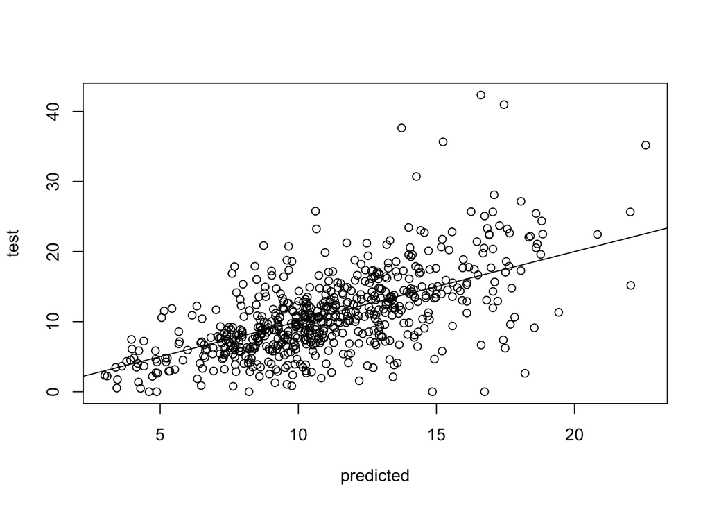

```r
preds_rf_1 = predict(fit_rf_1, newdata = test_set_0415)
plot(preds_rf_1, test_set_0415$rate, xlab = "predicted", ylab = "test")
abline(0,1)
```

```r
sqrt(mean((preds_rf_1 - test_set_0415$rate)^2))
```

```
## [1] 4.661459
```

With Random Forest (`mtry = 18`), we got a RMSE of 4.66. To imporve prediction performance, we fitted another model with a smaller value for `mtry`. The default for regression trees is p/3, so we used `mtry = 6`.

```r
fit_rf_2 <- randomForest(rate ~ mean_pm25 + smoke + obese + poverty + no_grad + owner_occupied + hispanic_pct + blk_pct + age_pct_15_44 + age_pct_45_65 + age_pct_65_plus + population_density + median_house_value + median_household_income + mean_winter_temp + mean_summer_temp + mean_winter_rm + mean_summer_rm, data = train_set_0415, mtry = 6, importance = TRUE)
fit_rf_2
```

```
##
## Call:
##  randomForest(formula = rate ~ mean_pm25 + smoke + obese + poverty +      no_grad + owner_occupied + hispanic_pct + blk_pct + age_pct_15_44 +      age_pct_45_65 + age_pct_65_plus + population_density + median_house_value +      median_household_income + mean_winter_temp + mean_summer_temp +      …
##                Type of random forest: regression
##                      Number of trees: 500
## No. of variables tried at each split: 6
##
##           Mean of squared residuals: 21.67776
##                     % Var explained: 36.61
```

How well does model 2 perform?

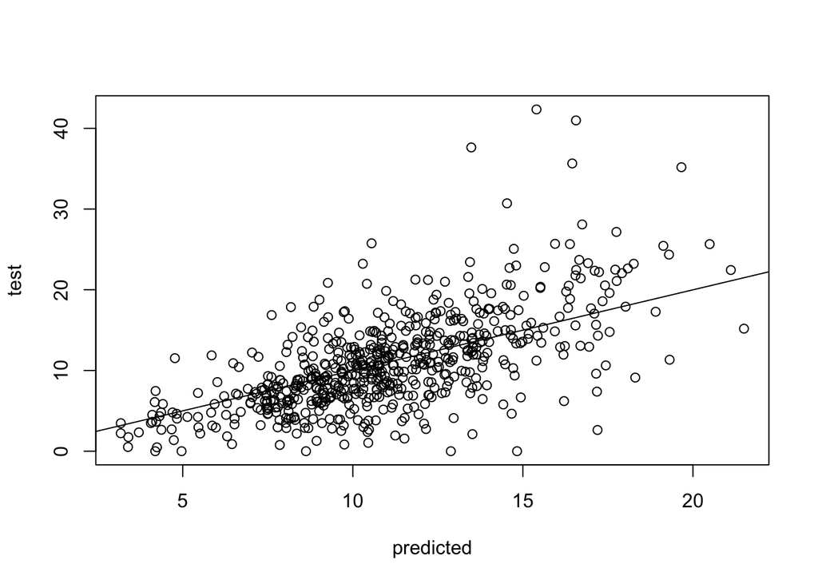

```r
preds_rf_2 = predict(fit_rf_2, newdata = test_set_0415)
plot(preds_rf_2, test_set_0415$rate, xlab = "predicted", ylab = "test")
abline(0,1)
```

```r
sqrt(mean((preds_rf_2 - test_set_0415$rate)^2))
```

```
## [1] 4.619547
```

With Random Forest (`mtry = 6`), we got a RMSE of 4.62, which is slightly better than model 1 with `mtry = 18`. We would like to examine variable importance from the random forest model.

```r
library(knitr)
variable_importance_0415 <- importance(fit_rf_2)
tmp_0415 <- tibble(feature = rownames(variable_importance_0415),
                  Gini = variable_importance_0415[,1]) %>%
                  arrange(desc(Gini))
kable(tmp_0415[1:10,])
```

| feature | Gini |
| --- | --- |
| median_house_value | 34.81935 |
| mean_summer_temp | 34.46988 |
| age_pct_45_65 | 28.27105 |
| mean_pm25 | 24.55491 |
| mean_winter_temp | 23.80711 |
| age_pct_65_plus | 23.20203 |
| smoke | 20.05610 |
| mean_summer_rm | 18.66723 |
| median_household_income | 18.19160 |
| age_pct_15_44 | 17.81186 |

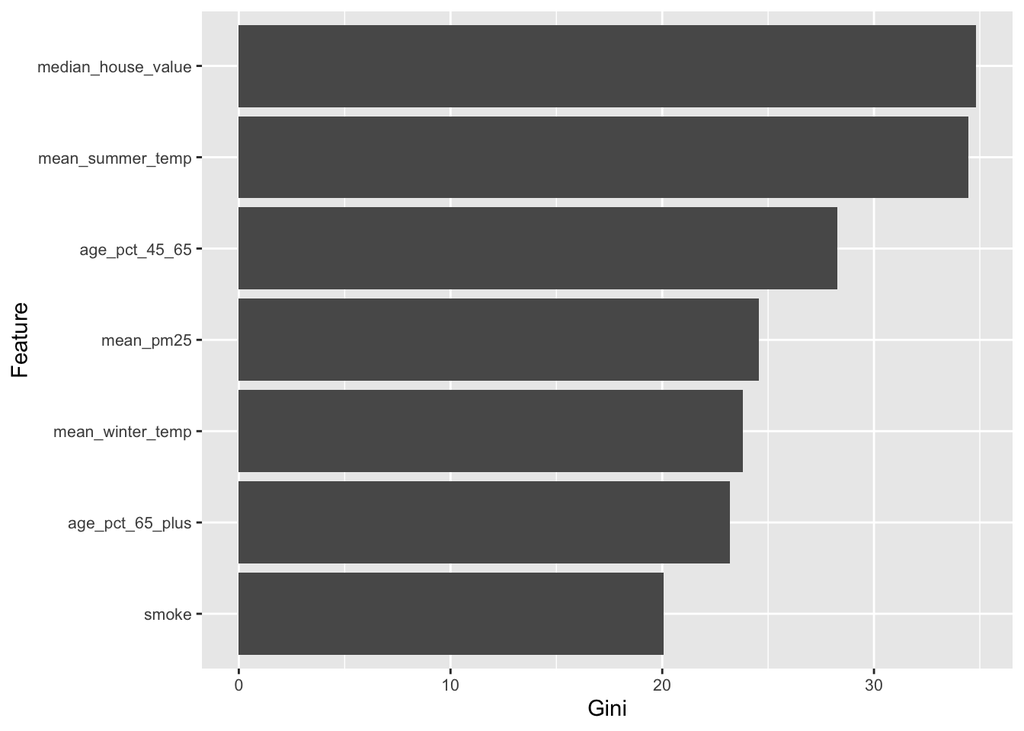

```r
tmp_0415 %>% filter(Gini > 20) %>%
        ggplot(aes(x=reorder(feature, Gini), y=Gini)) +
        geom_bar(stat='identity') +
        coord_flip() + xlab("Feature") +
        theme(axis.text=element_text(size=8))
```

The top 10 important predictors are: median house value, average summer temperature, % 45-65 years of age, average pm 2.5, average winter temperature, % >= 65 years of age, % smokers, average summer relative humidity, median household income, and % 15-44 years of age.

Based on predictor importance, we fitted a Random Forest model to the training set that predicts `rate` based `median_house_value`, `mean_summer_temp`, `age_pct_45_65`, `mean_pm25`, `mean_winter_temp`, `age_pct_65_plus`, and `smoke`. There are 7 predictors, so we tried `mtry = 2`

```r
set.seed(1)
fit_rf_3 <- randomForest(rate ~ mean_summer_temp + median_house_value + mean_pm25 + age_pct_65_plus + age_pct_45_65 + mean_winter_temp + smoke, data = train_set_0415, mtry = 2, importance = TRUE)
fit_rf_3
```

```
##
## Call:
##  randomForest(formula = rate ~ mean_summer_temp + median_house_value +      mean_pm25 + age_pct_65_plus + age_pct_45_65 + mean_winter_temp +      smoke, data = train_set_0415, mtry = 2, importance = TRUE)
##                Type of random forest: regression
##                      Number of trees: 500
## No. of variables tried at each split: 2
##
##           Mean of squared residuals: 21.9404
##                     % Var explained: 35.84
```

How well does model 3 perform?

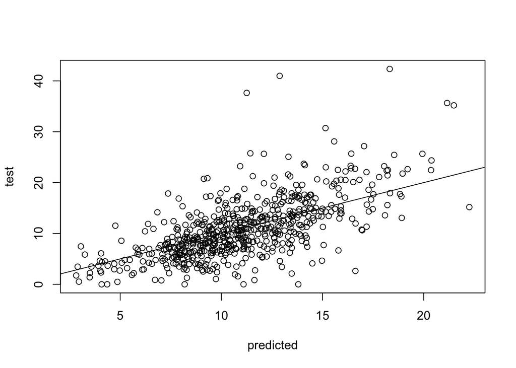

```r
preds_rf_3 = predict(fit_rf_3, newdata = test_set_0415)
plot(preds_rf_3, test_set_0415$rate, xlab = "predicted", ylab = "test")
abline(0,1)
```

```r
sqrt(mean((preds_rf_3 - test_set_0415$rate)^2))
```

```
## [1] 4.543007
```

For model 3 (`mtry = 2`) with only the top 7 most important predictors, we got a RMSE of 4.54, which is better than the previous models.

### Random Forest Model with complete data up until 10/31/2021

We explored how widespread availabilty of vaccines potentially changed the importance of predictors in our models. Therefore, we carried out the following analysis using the complete dataset that contains COVID-19 mortality rate after the introduction of vaccines.

### Step 1: Split data

We used a 80% training, 20% test set split. We have 2464 observations in the training dataset and 614 observations in the test dataset.

```r
df_1031 <- df_1031 %>%
   mutate(Mortality_bin = as.factor(ifelse(rate >= median(rate), 1, 0)))

set.seed(1)

index_train_1031 <- createDataPartition(y = df_1031$rate, times =1, p=0.8, list = FALSE)
train_set_1031 <- slice(df_1031, index_train_1031)
test_set_1031 <- slice(df_1031, -index_train_1031)
dim(train_set_1031)
```

```
## [1] 2464   34
```

```r
dim(test_set_1031)
```

```
## [1] 614  34
```

### Step 2: Machine Learning Analysis

We fitted a Random Forest model to the training set that predicts `rate` based on all of the other variables. Still, we used `mtry = 18`, which indicates all 18 predictors should be considered for each split of the tree.

```r
set.seed(1)

fit_rf_4 <- randomForest(rate ~ mean_pm25 + smoke + obese + poverty + no_grad + owner_occupied + hispanic_pct + blk_pct + age_pct_15_44 + age_pct_45_65 + age_pct_65_plus + population_density + median_house_value + median_household_income + mean_winter_temp + mean_summer_temp + mean_winter_rm + mean_summer_rm, data = train_set_1031, mtry = 18, importance = TRUE)
fit_rf_4
```

```
##
## Call:
##  randomForest(formula = rate ~ mean_pm25 + smoke + obese + poverty +      no_grad + owner_occupied + hispanic_pct + blk_pct + age_pct_15_44 +      age_pct_45_65 + age_pct_65_plus + population_density + median_house_value +      median_household_income + mean_winter_temp + mean_summer_temp +      …
##                Type of random forest: regression
##                      Number of trees: 500
## No. of variables tried at each split: 18
##
##           Mean of squared residuals: 29.44289
##                     % Var explained: 41.82
```

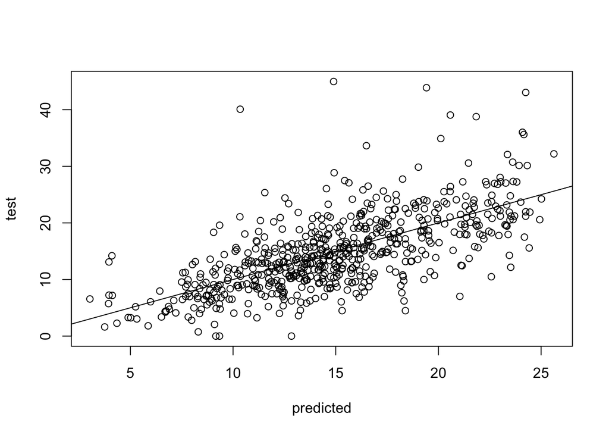

```r
preds_rf_4 = predict(fit_rf_4, newdata = test_set_1031)
plot(preds_rf_4, test_set_1031$rate, xlab = "predicted", ylab = "test")
abline(0,1)
```

```r
sqrt(mean((preds_rf_4 - test_set_1031$rate)^2))
```

```
## [1] 5.131987
```

When performing the random forest model (`mtry = 18`) fitting the dataset that contains COVID-19 mortality up until 10/31/2021, we got a RMSE of 5.13. So, we fitted another model with a smaller value of `mtry = 6`.

```r
set.seed(1)
fit_rf_5 <- randomForest(rate ~ mean_pm25 + smoke + obese + poverty + no_grad + owner_occupied + hispanic_pct + blk_pct + age_pct_15_44 + age_pct_45_65 + age_pct_65_plus + population_density + median_house_value + median_household_income + mean_winter_temp + mean_summer_temp + mean_winter_rm + mean_summer_rm, data = train_set_1031, mtry = 6, importance = TRUE)
fit_rf_5
```

```
##
## Call:
##  randomForest(formula = rate ~ mean_pm25 + smoke + obese + poverty +      no_grad + owner_occupied + hispanic_pct + blk_pct + age_pct_15_44 +      age_pct_45_65 + age_pct_65_plus + population_density + median_house_value +      median_household_income + mean_winter_temp + mean_summer_temp +      …
##                Type of random forest: regression
##                      Number of trees: 500
## No. of variables tried at each split: 6
##
##           Mean of squared residuals: 29.06043
##                     % Var explained: 42.57
```

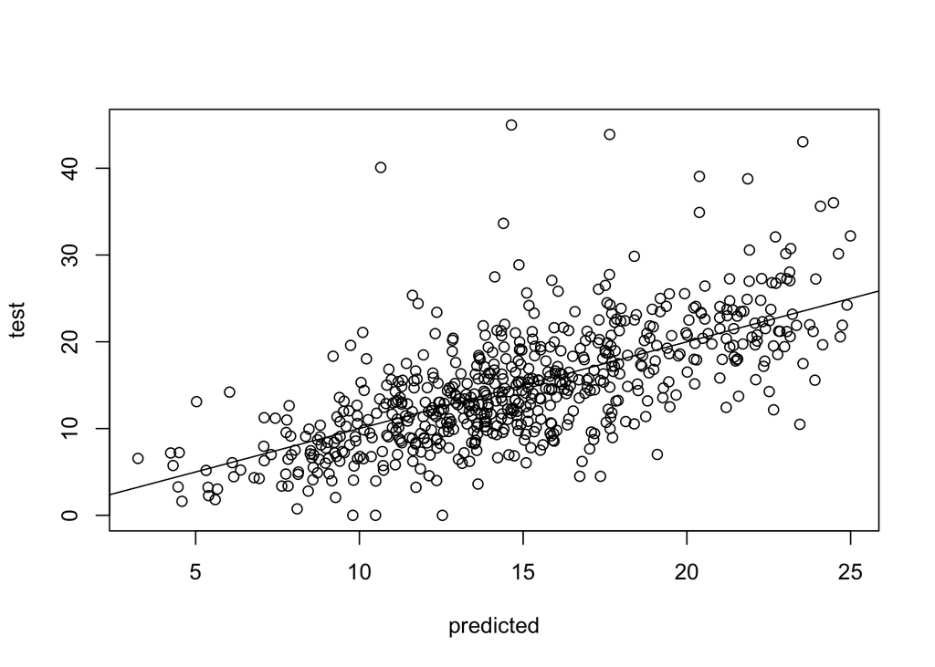

```r
preds_rf_5 = predict(fit_rf_5, newdata = test_set_1031)
plot(preds_rf_5, test_set_1031$rate, xlab = "predicted", ylab = "test")
abline(0,1)
```

```r
sqrt(mean((preds_rf_5 - test_set_1031$rate)^2))
```

```
## [1] 5.090712
```

With Random Forest (`mtry = 6`), we got a RMSE of 5.09, which performs better than the model with `mtry = 18`. So, we would like to see the predictor importance of this model

```r
library(knitr)
variable_importance_1031 <- importance(fit_rf_5)
tmp_1031 <- tibble(feature = rownames(variable_importance_1031),
                  Gini = variable_importance_1031[,1]) %>%
                  arrange(desc(Gini))
kable(tmp_1031[1:10,])
```

| feature | Gini |
| --- | --- |
| mean_summer_temp | 41.85194 |
| median_house_value | 31.79968 |
| smoke | 30.73422 |
| age_pct_65_plus | 26.43945 |
| median_household_income | 24.13250 |
| no_grad | 23.89202 |
| mean_pm25 | 23.60240 |
| mean_winter_temp | 23.44030 |
| age_pct_45_65 | 23.41259 |
| age_pct_15_44 | 21.22292 |

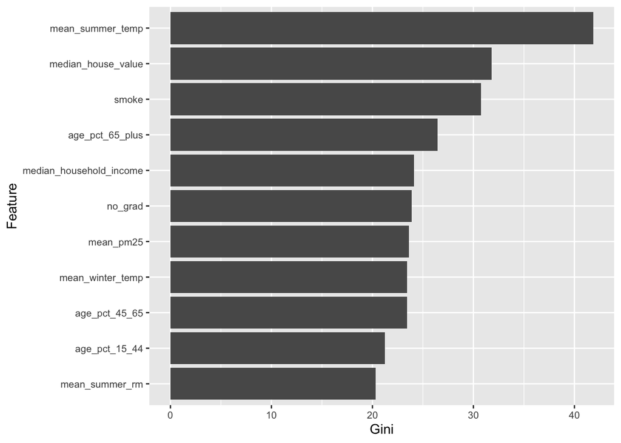

```r
tmp_1031 %>% filter(Gini > 20) %>%
        ggplot(aes(x=reorder(feature, Gini), y=Gini)) +
        geom_bar(stat='identity') +
        coord_flip() + xlab("Feature") +
        theme(axis.text=element_text(size=8))
```

Now, the top 10 important predictors have changed: average summer temperature, median house value, % smokers, % >= 65 years of age, median household income, % less than high school education, average pm 2.5, average winter temperature, % 45-65 years of age, % 15-44 years of age, and average summer relative humidity.

It is important to note that the rank of `mean_pm25` has dropped when using the dataset that contains information after the introduction of vaccines. While evironmental and socioeconomic factors, such as summer temperature and house values, continue to play an important role in predicting COVID-19 mortality rate, the impact of pm 2.5 seems to be alleviated after when taking vaccination into account. Therefore, it is possible that vaccaination has mitigated the negative effect of the long-term pm 2.5 exposure on COVID-19 mortality.

We fitted another moodel with the top 7 important predictors:

```r
set.seed(1)
fit_rf_6 <- randomForest(rate ~ mean_summer_temp + median_house_value + smoke + age_pct_65_plus + median_household_income +  no_grad + mean_pm25, data = train_set_1031, mtry = 2, importance = TRUE)
fit_rf_6
```

```
##
## Call:
##  randomForest(formula = rate ~ mean_summer_temp + median_house_value +      smoke + age_pct_65_plus + median_household_income + no_grad +      mean_pm25, data = train_set_1031, mtry = 2, importance = TRUE)
##                Type of random forest: regression
##                      Number of trees: 500
## No. of variables tried at each split: 2
##
##           Mean of squared residuals: 30.85294
##                     % Var explained: 39.03
```

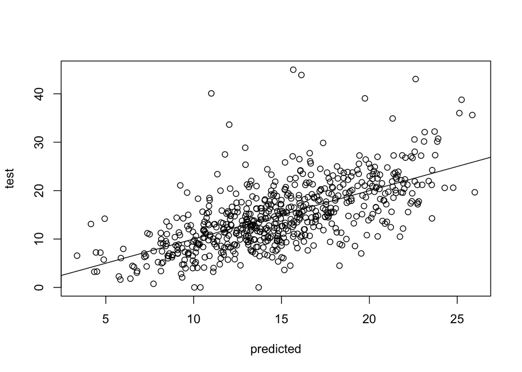

```r
preds_rf_6 = predict(fit_rf_6, newdata = test_set_1031)
plot(preds_rf_6, test_set_1031$rate, xlab = "predicted", ylab = "test")
abline(0,1)
```

```r
sqrt(mean((preds_rf_6 - test_set_1031$rate)^2))
```

```
## [1] 5.250154
```

There an increase in RMSE (5.25) when using the top 7 important predictors.

### Random Forest Model with binary outcome (using complete data up until 10/31/2021)

To better understand variable importance and imporve model performance, we fitted a Random Forest model to the training set that predicts `Mortality_bin` based on all of the other variables. Then, we used the predict function to get probability estimates for the test set, and convert the probabilities to predicted response labels (use a cutoff of 0.5). Still, we used `mtry = 18`.

```r
set.seed(1)

fit_rf_7 <- randomForest(Mortality_bin ~ mean_pm25 + smoke + obese + poverty + no_grad + owner_occupied + hispanic_pct + blk_pct + age_pct_15_44 + age_pct_45_65 + age_pct_65_plus + population_density + median_house_value + median_household_income + mean_winter_temp + mean_summer_temp + mean_winter_rm + mean_summer_rm, data = train_set_1031, mtry = 18, importance = TRUE)
```

```r
preds_rf_7 = predict(fit_rf_7, newdata = test_set_1031, type = "prob")[,2]
y_hat_rf_7 = factor(ifelse(preds_rf_7 > 0.5, 1, 0))
confusionMatrix(data = as.factor(y_hat_rf_7), reference = as.factor(test_set_1031$Mortality_bin), positive = "1")
```

```
## Confusion Matrix and Statistics
##
##           Reference
## Prediction   0   1
##          0 233  75
##          1  74 232
##
##                Accuracy : 0.7573
##                  95% CI : (0.7214, 0.7907)
##     No Information Rate : 0.5
##     P-Value [Acc > NIR] : <2e-16
##
##                   Kappa : 0.5147
##
##  Mcnemar's Test P-Value : 1
##
##             Sensitivity : 0.7557
##             Specificity : 0.7590
##          Pos Pred Value : 0.7582
##          Neg Pred Value : 0.7565
##              Prevalence : 0.5000
##          Detection Rate : 0.3779
##    Detection Prevalence : 0.4984
##       Balanced Accuracy : 0.7573
##
##        'Positive' Class : 1
##
```

Model 7 (`mtry = 18`) had an overall accuracy of 75.7% with a sensitivity of 75.6% and specificity of 75.9%. We tried another model to predict the binary outcome `Mortality_bin` with `mtry = 6`.

```r
set.seed(1)
fit_rf_8 <- randomForest(Mortality_bin ~ mean_pm25 + smoke + obese + poverty + no_grad + owner_occupied + hispanic_pct + blk_pct + age_pct_15_44 + age_pct_45_65 + age_pct_65_plus + population_density + median_house_value + median_household_income + mean_winter_temp + mean_summer_temp + mean_winter_rm + mean_summer_rm, data = train_set_1031, mtry = 6, importance = TRUE)
```

```r
preds_rf_8 = predict(fit_rf_8, newdata = test_set_1031, type = "prob")[,2]
y_hat_rf_8 = factor(ifelse(preds_rf_8 > 0.5, 1, 0))
confusionMatrix(data = as.factor(y_hat_rf_8), reference = as.factor(test_set_1031$Mortality_bin), positive = "1")
```

```
## Confusion Matrix and Statistics
##
##           Reference
## Prediction   0   1
##          0 238  73
##          1  69 234
##
##                Accuracy : 0.7687
##                  95% CI : (0.7333, 0.8015)
##     No Information Rate : 0.5
##     P-Value [Acc > NIR] : <2e-16
##
##                   Kappa : 0.5375
##
##  Mcnemar's Test P-Value : 0.8012
##
##             Sensitivity : 0.7622
##             Specificity : 0.7752
##          Pos Pred Value : 0.7723
##          Neg Pred Value : 0.7653
##              Prevalence : 0.5000
##          Detection Rate : 0.3811
##    Detection Prevalence : 0.4935
##       Balanced Accuracy : 0.7687
##
##        'Positive' Class : 1
##
```

Model 8 (`mtry = 6`) had an overall accuracy of 76.9% with a sensitivity of 76.2% and specificity of 77.5%. There’s an increase in overall accuracy as well as in sensitivity and specificity. We further explored variable importance of this model.

```r
library(knitr)
variable_importance_m8 <- importance(fit_rf_8)
tmp_m8 <- tibble(feature = rownames(variable_importance_m8),
                  Gini = variable_importance_m8[,1]) %>%
                  arrange(desc(Gini))
kable(tmp_m8[1:10,])
```

| feature | Gini |
| --- | --- |
| mean_summer_temp | 30.864363 |
| median_house_value | 26.278221 |
| smoke | 22.185291 |
| no_grad | 16.775236 |
| hispanic_pct | 16.475686 |
| median_household_income | 15.032029 |
| age_pct_65_plus | 14.282034 |
| age_pct_45_65 | 14.055613 |
| population_density | 9.691783 |
| mean_pm25 | 8.722775 |

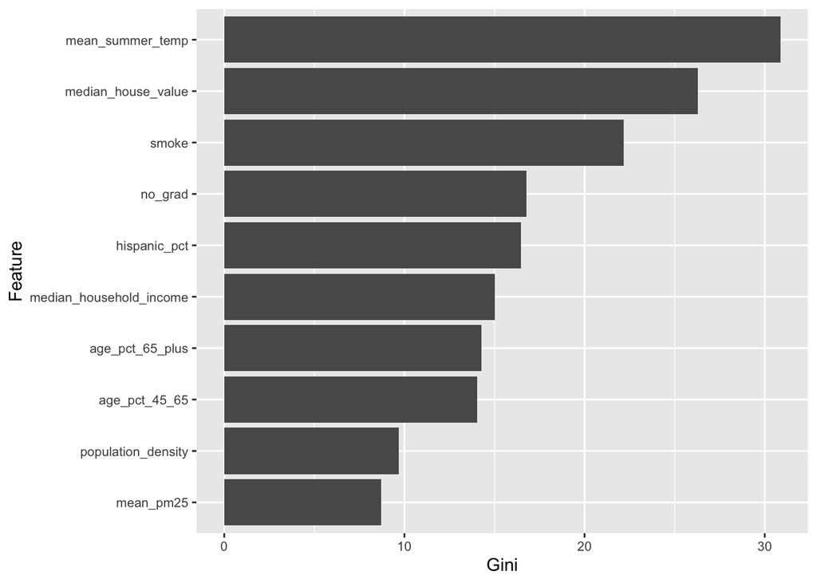

```r
tmp_m8 %>% filter(Gini > 8.7) %>%
        ggplot(aes(x=reorder(feature, Gini), y=Gini)) +
        geom_bar(stat='identity') +
        coord_flip() + xlab("Feature") +
        theme(axis.text=element_text(size=8))
```

The top 10 important predictors are: average summer temperature, median house value, % smokers, % less than high school education, % hispanic, median household income, % >= 65 years of age, % 45-65 years of age, population density, and average pm 2.5.

For the model using binary outcome, we observed that the rank of `mean_pm25` has dropped significantly. For classification, the importance of pm 2.5 has been greatly reduced.

Then, we used variables that are the most predictive of the outcome to fit the following model:

```r
set.seed(1)
fit_rf_9 <- randomForest(Mortality_bin ~ mean_summer_temp + median_house_value + smoke + no_grad + hispanic_pct + median_household_income + age_pct_45_65 + age_pct_65_plus + population_density + mean_pm25, data = train_set_1031, mtry = 3, importance = TRUE)
```

```r
preds_rf_9 = predict(fit_rf_9, newdata = test_set_1031, type = "prob")[,2]
y_hat_rf_9 = factor(ifelse(preds_rf_9 > 0.5, 1, 0))
confusionMatrix(data = as.factor(y_hat_rf_9), reference = as.factor(test_set_1031$Mortality_bin), positive = "1")
```

```
## Confusion Matrix and Statistics
##
##           Reference
## Prediction   0   1
##          0 241  74
##          1  66 233
##
##                Accuracy : 0.772
##                  95% CI : (0.7367, 0.8046)
##     No Information Rate : 0.5
##     P-Value [Acc > NIR] : <2e-16
##
##                   Kappa : 0.544
##
##  Mcnemar's Test P-Value : 0.5541
##
##             Sensitivity : 0.7590
##             Specificity : 0.7850
##          Pos Pred Value : 0.7793
##          Neg Pred Value : 0.7651
##              Prevalence : 0.5000
##          Detection Rate : 0.3795
##    Detection Prevalence : 0.4870
##       Balanced Accuracy : 0.7720
##
##        'Positive' Class : 1
##
```

Using important predictors, model 9 had an overall accuracy of 77.2% with a sensitivity of 75.9% and specificity of 78.5%. Overall, this is the best model for classification.